# Higher-order networks: three readings of one dataset

honets

2026-08-26

> Each section below is one verb, worked end to end on the same data. The sections run in order in a single R session, so later ones may reuse objects the earlier ones built.

## Three higher-order readings of one dataset

### The analytic question

“Higher-order network” names three different objects in the literature, and they are usually treated as three literatures. A network is higher-order when a relation reaches past a single pair of nodes at a single moment — but there are two distinct ways to reach past it, and three structures that do so:

- a relation can depend on **more than the current node** — a *memory network*;
- a relation can bind **more than two nodes at once**, either as a set whose every subset is also a relation — a *simplicial complex* — or as a set with no such requirement — a *hypergraph*.

This tutorial puts all three on the same data and asks a question that only a single package can ask cleanly: **do they agree?** If they did, the choice among them would be a matter of taste. They do not, and where they disagree is the finding.

The data are `human_long`, bundled with honets: 10,796 coded human turns from 429 human-AI pair-programming sessions, nine action codes.

```r
library(honets)
```

```r
library(cograph)
```

### The baseline says nothing

Before reaching for any higher-order structure, run the first-order one. It is the model that must be beaten.

```r
fo <- build_hon(human_long, action = "code", actor = "session_id",
                time = "timestamp", max_order = 1, min_freq = 5)
hon_centrality(fo)
```

```
      state  pagerank betweenness closeness
1   Command 0.1111111           0         8
2   Correct 0.1111111           0         8
3 Frustrate 0.1111111           0         8
4   Inquire 0.1111111           0         8
5 Interrupt 0.1111111           0         8
6    Refine 0.1111111           0         8
7   Request 0.1111111           0         8
8   Specify 0.1111111           0         8
9    Verify 0.1111111           0         8
```

Every action gets PageRank exactly 1/9, closeness exactly 8, betweenness exactly 0. That is not a numerical coincidence. With 10,796 turns over nine codes, every one of the 81 possible transitions occurs at least five times, so the first-order network is the *complete digraph* on nine nodes. Every node has the same in-degree, which forces PageRank uniform; every pair is one step apart, which forces closeness constant and betweenness zero.

The first-order network is structurally incapable of ranking these actions. No choice of centrality repairs that — the information is not in the topology. Everything below is an attempt to put it back.

### Reading 1 — memory: what follows what, given how you got here

A memory network makes a node a state *plus the memory of how it was reached*, so `Specify -> Command` is a different object from `Inquire -> Command`, with its own continuation distribution.

```r
hon <- build_hon(human_long, action = "code", actor = "session_id",
                 time = "timestamp", max_order = 3, min_freq = 5)
hon
```

```
Higher-Order Network (HON)
  Nodes:        233 (9 first-order states)
  Edges:        819
  Max order:    3 (requested 3)
  Min freq:     5
  Trajectories: 425
```

```r
hon_centrality(hon, type = "pagerank", sort_by = "pagerank")
```

```
      state   pagerank
1   Specify 0.23396968
2   Command 0.18365067
3   Inquire 0.10991607
4 Frustrate 0.10421334
5   Request 0.09503177
6    Refine 0.08850329
7   Correct 0.07833723
8 Interrupt 0.06438203
9    Verify 0.04199591
```

Nine states, but 233 nodes: the extra 224 are memory contexts. And now the actions separate over a 5.6-fold range — Specify holds 23.4% of the flow, Command 18.4%, down to Verify at 4.2%.

This is a claim about **flow**: where a walker that respects the sequences’ memory spends its time.

The memory reading, drawn. The object to draw is `fo`, the **first-order** network from the opening section — nine states. The higher-order network has 233 nodes and drawing it produces a hairball, so the memory structure goes on top of the nine-node layout as pathways rather than becoming the layout.

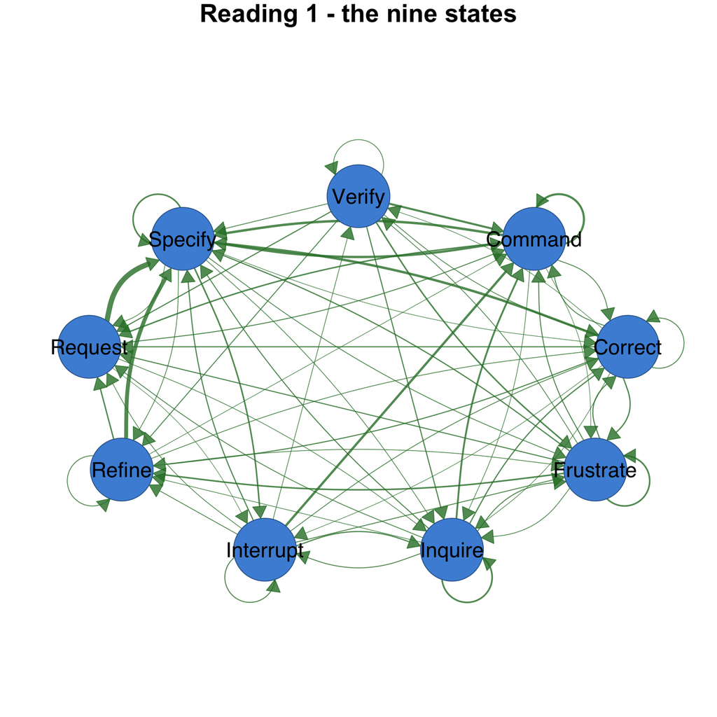

```r
splot(fo, minimum = 0.05, title = "Reading 1 - the nine states")
```

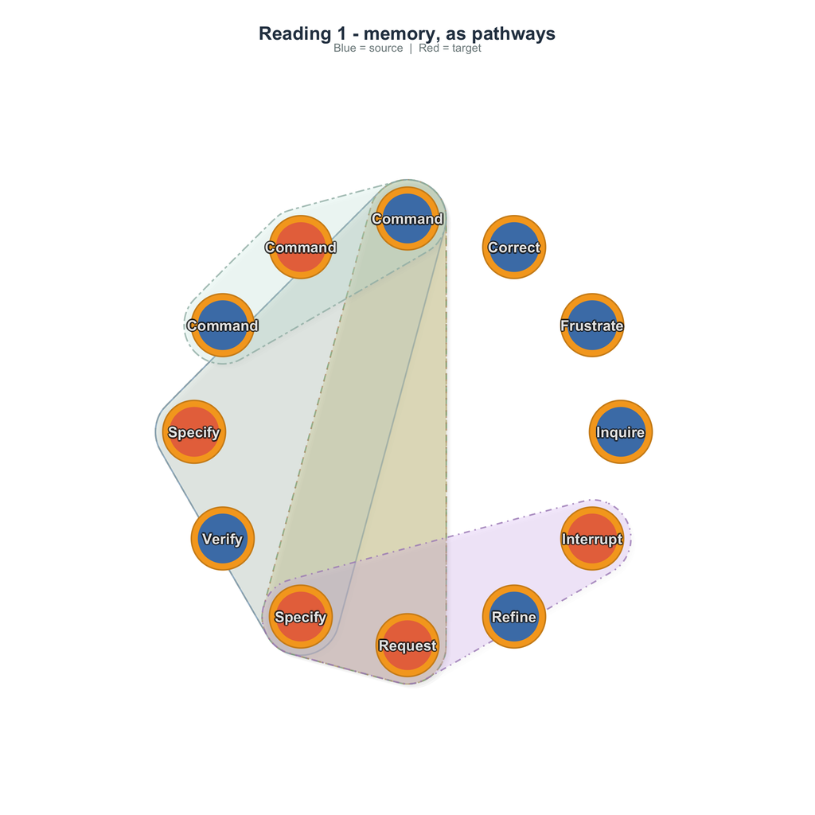

```r
contexts_top <- as.data.frame(hon, order_min = 2, sort_by = "count", top = 6)
plot_simplicial(fo,
                pathways = contexts_top,
                max_pathways = 6,
                title = "Reading 1 - memory, as pathways")
```

### Reading 2 — simplicial: which actions co-occur as coherent groups

The same fitted memory network can be read as a *pathway complex*: every observed path becomes a simplex, and — this is what makes it simplicial — so does every sub-path of it. That closure is what gives the object a geometry.

```r
sc <- build_simplicial(hon, type = "pathway")
sc
```

```
Pathway Complex
  9 nodes, 157 simplices, dimension 3
  Density: 61.6%  |  Mean dim: 1.87  |  Euler: 19
  f-vector: (f0=9 f1=36 f2=79 f3=33)
  Betti: b0=1 b2=18
  Nodes: Command, Correct, Frustrate, Inquire, Interrupt, Refine, Request, Specify, Verify
```

```r
as.data.frame(sc, what = "f_vector")
```

```
  dim count
1   0     9
2   1    36
3   2    79
4   3    33
```

Nine nodes carry 157 simplices up to dimension 3: 36 edges, 79 triangles, 33 tetrahedra. Density 61.6% — most of the combinations that *could* appear do.

Because it has a geometry, it has a topology:

```r
betti_numbers(sc)
```

```
b0 b1 b2 b3
 1  0 18  0
```

```r
euler_characteristic(sc)
```

```
[1] 19
```

`b0 = 1` says the complex is connected — no group of actions is isolated from the rest. `b1 = 0` says there are no one-dimensional holes: any loop of actions can be filled in by observed pathways. `b2 = 18` says there are **18 independent two-dimensional voids** — configurations of four actions where every triple was observed but the four-way combination never was. Those are the near-misses of this corpus: patterns the sessions came right up to the edge of and never completed.

Per-action, the simplicial reading is a count of memberships:

```r
simplicial_degree(sc)
```

```
       node d0 d1 d2 d3 total
8   Specify  1  8 28 32    68
1   Command  1  8 28 19    55
7   Request  1  8 26 15    49
2   Correct  1  8 26 12    46
3 Frustrate  1  8 26 12    46
4   Inquire  1  8 25 13    46
6    Refine  1  8 27 11    46
5 Interrupt  1  8 26 10    44
9    Verify  1  8 25  8    41
```

Specify sits in 68 simplices, Verify in 41. Note the shape of the table: `d0`/`d1` are identical for every action (each is in one vertex and eight edges — a consequence of the saturated first-order structure), so the whole signal is in `d2` and `d3`. The discrimination lives entirely in the three- and four-way combinations.

The simplicial reading, drawn. This one has its own `plot()` method, and it is the right picture: face counts by dimension, the Betti numbers, and each action’s simplicial degree. The blob diagram above showed *which* pathways; this shows the shape they add up to.

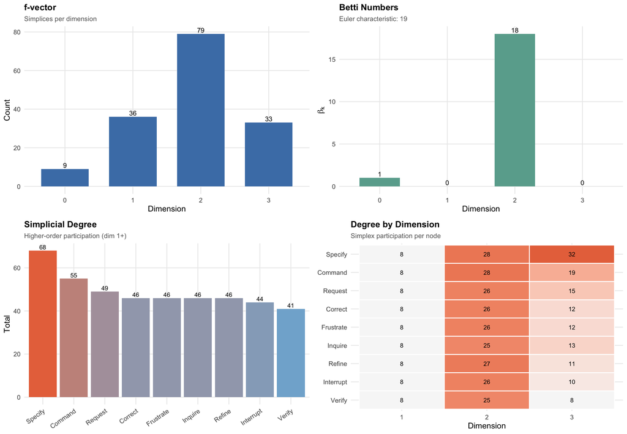

```r
plot(sc)
```

### Reading 3 — hypergraph: which actions belong to the same session

A hypergraph drops the closure requirement: a set of nodes can be a relation without any of its subsets being one. That fits observed group membership exactly. Each session is one hyperedge over the codes it contains.

```r
hg <- group_hypergraph(human_long, actor = "code", group = "session_id")
hg
```

```
Hypergraph: 9 nodes, 429 hyperedges
Size distribution:
  size_1   : 5
  size_2   : 3
  size_3   : 20
  size_4   : 32
  size_5   : 62
  size_6   : 77
  size_7   : 75
  size_8   : 75
  size_9   : 80
Source: group membership (member = code, group = session_id)
```

```r
measures <- hypergraph_measures(hg)
as.data.frame(measures, what = "global")
```

```
                 measure       value
1                n_nodes   9.0000000
2           n_hyperedges 429.0000000
3                density   0.7293447
4          avg_edge_size   6.5641026
5 pairwise_participation   1.0000000
```

429 hyperedges — one per session — averaging 6.6 actions each. The distribution is heavily weighted toward large sessions: 80 of the 429 sessions use all nine codes.

```r
hypergraph_centrality(hg, type = "pagerank", sort_by = "pagerank")
```

```
       node   pagerank
1   Command 0.14396265
2   Specify 0.14158683
3 Interrupt 0.13500987
4   Request 0.12297636
5   Correct 0.09773453
6   Inquire 0.09562551
7 Frustrate 0.09298612
8    Refine 0.08727062
9    Verify 0.08284752
```

This is a claim about **co-membership**: how much of a random walk that hops action → session → action lands on each action.

The hypergraph reading, drawn. A hypergraph has no direct network picture, so it goes through `clique_expansion()` — and the caption has to say so, because the projection is a lossy one.

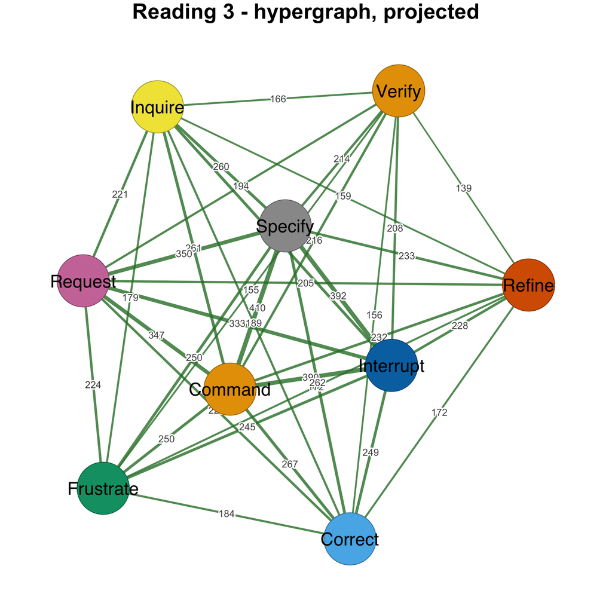

```r
net <- clique_expansion(hg)
splot(net, minimum = 0.05,
      title = "Reading 3 - hypergraph, projected")
```

Three pictures of the same 10,796 turns. The first is directed and carries memory; the second is undirected and carries closure; the third is undirected, complete, and carries only co-membership weight. Nothing about the data changed — only the question.

### Do the three agree?

Three tidy tables, joined in two steps. Nothing here reaches into a result object.

```r
pr_memory <- hon_centrality(hon, type = "pagerank")
deg_simplicial <- simplicial_degree(sc)
pr_hypergraph <- hypergraph_centrality(hg, type = "pagerank")
cmp <- merge(pr_memory, deg_simplicial, by.x = "state", by.y = "node")
cmp <- merge(cmp, pr_hypergraph, by.x = "state", by.y = "node",
             suffixes = c("_memory", "_hypergraph"))
cmp
```

```
      state pagerank_memory d0 d1 d2 d3 total pagerank_hypergraph
1   Command      0.18365067  1  8 28 19    55          0.14396265
2   Correct      0.07833723  1  8 26 12    46          0.09773453
3 Frustrate      0.10421334  1  8 26 12    46          0.09298612
4   Inquire      0.10991607  1  8 25 13    46          0.09562551
5 Interrupt      0.06438203  1  8 26 10    44          0.13500987
6    Refine      0.08850329  1  8 27 11    46          0.08727062
7   Request      0.09503177  1  8 26 15    49          0.12297636
8   Specify      0.23396968  1  8 28 32    68          0.14158683
9    Verify      0.04199591  1  8 25  8    41          0.08284752
```

```r
cmp_ranks <- subset(cmp, select = c(pagerank_memory, total, pagerank_hypergraph))
cor(cmp_ranks, method = "spearman")
```

```
                    pagerank_memory     total pagerank_hypergraph
pagerank_memory           1.0000000 0.8703883           0.5500000
total                     0.8703883 1.0000000           0.6789029
pagerank_hypergraph       0.5500000 0.6789029           1.0000000
```

The memory and simplicial readings agree strongly (Spearman 0.87) — both are built from the same fitted pathways, so this is a consistency check rather than independent evidence. The interesting number is **0.55**: memory flow and hypergraph co-membership rank these nine actions *differently*.

Two actions carry that disagreement, in opposite directions.

**Interrupt** is 8th of 9 by memory flow (0.064) and 3rd by co-membership (0.135). It appears in 393 of the 429 sessions — third highest hyperdegree — yet the transitions into and out of it are not on heavily travelled paths. Interrupt is *ubiquitous but peripheral*: almost every session contains one, and almost none is organised around it.

**Frustrate** runs the other way: 4th by memory flow (0.104), 7th by co-membership (0.093). It shows up in fewer sessions (252) but when it does, it sits on paths the walk keeps returning to. Frustration is *localised but consequential*.

Neither reading is wrong. They answer different questions, and an analysis that reports only one of them will describe Interrupt as either a central action or a marginal one, with no way to see that both are true.

### Crossing back

The families are entry points into one another. A hypergraph projects back to an ordinary pairwise network, which any first-order tool accepts:

```r
net <- clique_expansion(hg)
summary(net)
```

```
Cograph Network Summary
======================

Structure:
  Nodes: 9
  Edges: 36
  Type: Undirected

Edge Statistics:
  Min weight: 139
  Max weight: 410
  Mean weight: 238.472

Node Labels:
   Command, Correct, Frustrate, Inquire, Interrupt, Refine, Request, Specify, Verify

Layout: not computed
```

Nine nodes, 36 edges — the complete undirected graph, weighted by how often each pair shared a session. Compare that to the first-order network this tutorial opened with: same saturation, but now the *weights* carry the co-membership information, so the projection is not the degenerate object the transition network was.

### Choosing a reading

- **Memory network** (`build_hon()`) — the question is about *order and history*: what follows what, and does the past matter. Check `markov_order_test()` first: if memory is not there, the simpler model should be reported.
- **Simplicial complex** (`build_simplicial()`) — the question is about *coherent groups and their geometry*: which combinations hold together, and what is conspicuously missing. `betti_numbers()` finds the absences; a first-order summary can only report presences.
- **Hypergraph** (`group_hypergraph()`, `window_hypergraph()`) — the question is about *co-membership*: which things belong to the same occasion, with no assumption that sub-groups are meaningful in themselves.
- **All three** — when an action’s role is contested. The gap between the readings is the finding, as it is for Interrupt here.

Two cautions. The simplicial reading above was built *from* the memory network, so its agreement with the memory ranking is partly structural; build it from an independently estimated network if you need the two to be independent evidence. And every number here is a point estimate — use `bootstrap_hon()` before reporting a memory-based ranking as a finding.

### See also

- Higher-order centrality — the memory family in depth, including which *contexts* carry the flow.
- Bootstrap and permutation inference — how stable a rule is under resampling.
- Windowed sequence hyperedges — the other route from sequences into the hypergraph family.
- Hypergraph PageRank — edge-dependent vertex weights, and when a hypergraph collapses to a pairwise graph.

### References

- Battiston, F., Cencetti, G., Iacopini, I., Latora, V., Lucas, M., Patania, A., Young, J.-G., & Petri, G. (2020). Networks beyond pairwise interactions: Structure and dynamics. *Physics Reports*, 874, 1-92.
- Bianconi, G. (2021). *Higher-Order Networks*. Cambridge University Press.
- Scholtes, I., Wider, N., & Garas, A. (2016). Higher-order aggregate networks in the analysis of temporal networks. *The European Physical Journal B*, 89, 61.
- Atkin, R. H. (1974). *Mathematical Structure in Human Affairs*. Heinemann.
- Chitra, U., & Raphael, B. J. (2019). Random walks on hypergraphs with edge-dependent vertex weights. *ICML 2019*, PMLR 97, 1172-1181.

## pathways(): the bridge between the three families

### The analytic question

The three structure families in honets are entry points into one another, not islands. `pathways()` is the generic that carries a fitted **memory network** across to the other two: it extracts the paths the model considers real and returns them as plain strings, which `build_simplicial(type = "pathway")` turns into a complex.

It is a small verb doing one job, and it is the reason a HON can be handed to a topological analysis without any manual reshaping.

```r
library(honets)
seqs <- split(human_long$code, human_long$session_id)
```

```r
library(cograph)
```

### Three methods, one generic

`pathways()` dispatches on `net_hon`, `net_hypa` and `net_mogen`. Each returns the paths that model regards as meaningful — which is a *different set* in each case, because the three models mean different things by “meaningful”.

```r
hon <- build_hon(seqs, max_order = 2, min_freq = 50)
p_hon <- pathways(hon)
length(p_hon)
```

```
[1] 25
```

```r
pathways(hon, top = 6)
```

```
[1] "Specify Command -> Specify"   "Command Request -> Specify"
[3] "Specify Command -> Request"   "Request Specify -> Interrupt"
[5] "Command Command -> Command"   "Command Specify -> Interrupt"
```

From a HON: the extracted rules — contexts that earned their own node. 25 of them at `min_freq = 50`.

```r
hp <- build_hypa(seqs, order = 2)
p_hypa <- pathways(hp)
length(p_hypa)
```

```
[1] 185
```

```r
pathways(hp, top = 4)
```

[output not shown]

[output cut: 78 more lines]

From HYPA: the **anomalous** paths — those significantly over- or under-represented against the degree-preserving null. 185 of them. Note the first entry, `Interrupt Interrupt -> Interrupt`: the same repeated- interruption pattern that `path_dependence()` flags as the highest-divergence context.

```r
mo <- build_mogen(seqs, max_order = 2)
p_mogen <- pathways(mo)
length(p_mogen)
```

```
[1] 702
```

```r
pathways(mo, top = 4)
```

```
[1] "Specify Command -> Specify"   "Command Request -> Specify"
[3] "Specify Command -> Request"   "Request Specify -> Interrupt"
```

From MOGen: every path in the fitted layer — 702, the complete second-order transition set, because a multi-order model does not prune.

### The format

Each string is `"<context states, space separated> -> <next state>"`. The context uses spaces so that the arrow separates history from continuation unambiguously.

```r
p_hon[1]
```

```
[1] "Specify Command -> Specify"
```

Read as: the context `Specify Command` continuing to `Specify`.

### Crossing to the simplicial family

```r
sc <- build_simplicial(hon, type = "pathway")
sc
```

```
Pathway Complex
  9 nodes, 29 simplices, dimension 2
  Density: 22.5%  |  Mean dim: 0.90  |  Euler: 1
  f-vector: (f0=9 f1=14 f2=6)
  Betti: b0=2 b1=1
  Nodes: Command, Correct, Frustrate, Inquire, Interrupt, Refine, Request, Specify, Verify
```

`build_simplicial()` calls `pathways()` internally — you rarely need to call it yourself. Each path becomes a simplex, and because a simplicial complex is closed under subsets, so does every sub-path. The result has a geometry, and therefore a topology: `b0 = 2` says the well-evidenced pathways fall into **two disconnected groups** of actions, and `b1 = 1` says there is one one-dimensional hole — a cycle of actions that is never closed by an observed pathway.

Neither statement is available from the transition network the paths came from.

### Seeing them

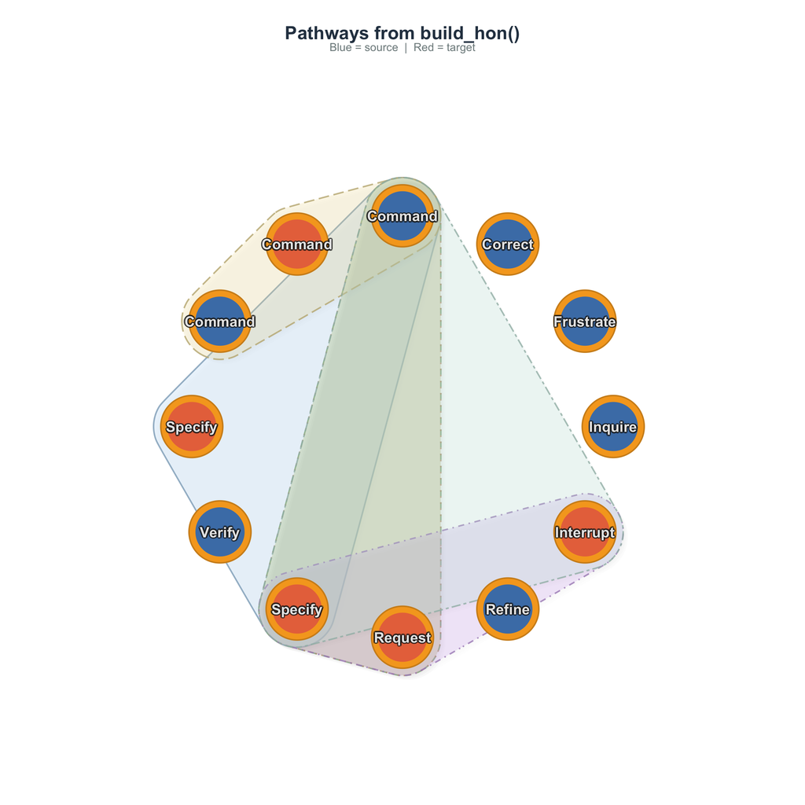

```r
net1 <- build_hon(seqs, max_order = 1)
contexts_top <- as.data.frame(hon, order_min = 2, sort_by = "count", top = 6)
plot_simplicial(net1,
                pathways = contexts_top,
                max_pathways = 6, title = "Pathways from build_hon()")
```

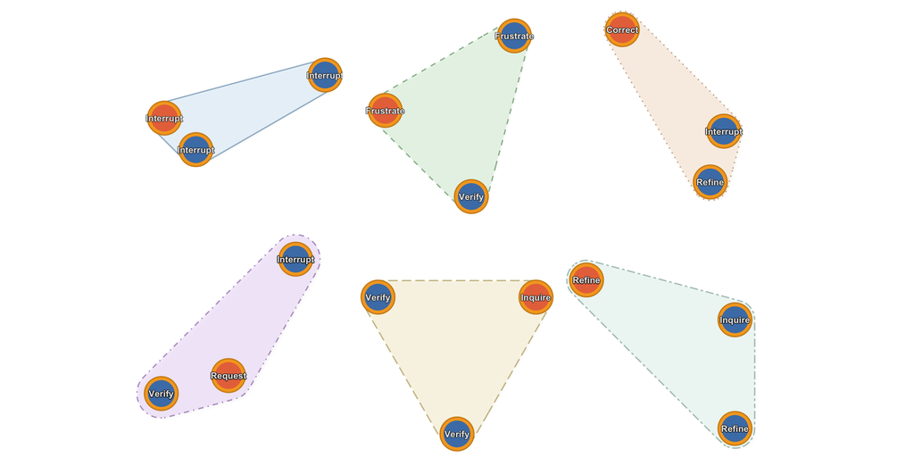

```r
plot_simplicial(hp, anomaly = "over", max_pathways = 6,
                dismantled = TRUE, ncol = 3)
```

### The choice of source model matters

Because the three models select different paths, they build different complexes:

```r
do.call(rbind, lapply(
  list(HON = hon, HYPA = hp, MOGen = mo),
  function(m) {
    p <- pathways(m)
    s <- build_simplicial(m, type = "pathway")
    f_vector <- as.data.frame(s, what = "f_vector")
    betti <- betti_numbers(s)
    data.frame(paths = length(p), simplices = sum(f_vector$count),
               dimension = max(f_vector$dim), b0 = betti[["b0"]])
  }))
```

```
      paths simplices dimension b0
HON      25        29         2  2
HYPA    185       105         2  1
MOGen   702       129         2  1
```

MOGen’s 702 unpruned paths produce a dense, connected complex; HON’s 25 well-evidenced rules produce a sparse, disconnected one. **The topology you report is a property of the model you chose**, not of the raw sequences — say which model, and say why.

### Calling it directly

You would call `pathways()` yourself to inspect what a model considers real, or to feed the paths somewhere else:

```r
# how long are the extracted paths?
table(lengths(strsplit(p_hon, " ", fixed = TRUE)))
```

```
 4
25
```

### What to do next

- **`build_simplicial()`** — the main consumer, and where the topology gets computed.
- **`build_hon()`**, **`build_hypa()`**, **`build_mogen()`** — the three producers.
- **`window_hypergraph()`** — the other route out of sequence data, into the hypergraph family.

### References

- Xu, J., Wickramarathne, T. L., & Chawla, N. V. (2016). Representing higher-order dependencies in networks. *Science Advances*, 2(5), e1600028.
- Battiston, F., et al. (2020). Networks beyond pairwise interactions. *Physics Reports*, 874, 1-92.